# Exc2A - The Phish from Vermont

Ido Algom & Natalie Gilboa

22/04/2016

## Introduction

Phish is an American rock and roll band noted for their musical improvisation, extended jams, blending of musical genres, and dedicated fan base. The Band Formed at the University of Vermont in 1983 (with the current line-up solidifying in 1985).

The Mockingbird Foundation is a charitable organization founded by fans of the jam band Phish in 1996 to support music education for children. The website Phish.net is a fan website that formally adopted by The Foundation as a project in 2005. The site had begun in 1991 and served Phish fans for nearly two decades as static HTML pages. It was re-launched as an integrated database - of setlists, song histories, reviews, and more - in fall 2009.

The website contains tables about each song that ever played in show. Every single show the band has been playing during the years has a unique setlist. This information about each song and each show is recorded at the website database for fans.

Let’s get some code - preparations

```r
require(gtable)
require(ggplot2)
library(gtable)
library(ggplot2)
```

We chose to explore the statistics about the songs. I copied the table about all the songs the band played during the years. The table contains the following columns:

- Song Name
- Original Artist (The band played a lot of cover songs)
- Time Played (At how many shows the song has played)
- Debut (Show date first time played)
- Last Played (Show date last time played)
- Gap (Amount of shows the song hasn’t played)

The last show was played in 2016/01/2016

```r
yem <- read.csv("phish.csv")
head(yem)
```

```
##                Song.Name Original.Artist Times.Played      Debut
## 1            Army of One           Phish           17 2003-07-12
## 2            Bathtub Gin           Phish          247 1989-05-26
## 3                    Bug        Amfibian           63 1999-06-24
## 4 Crosseyed and Painless   Talking Heads           37 1996-10-31
## 5      Down with Disease           Phish          261 1993-12-31
## 6              Farmhouse           Phish           62 1997-11-07
##    Last.Seen Current.Gap
## 1 2016-01-17           0
## 2 2016-01-17           0
## 3 2016-01-17           0
## 4 2016-01-17           0
## 5 2016-01-17           0
## 6 2016-01-17           0
```

## Basic Information

How many songs debuted at each day of the week. In this Graph we took the debut day and converted it to Date and to Weekdays with basic R functions.

The comment line is here to replace the bars arguments as Hebrew in Mac sometimes is not doing such a great job.

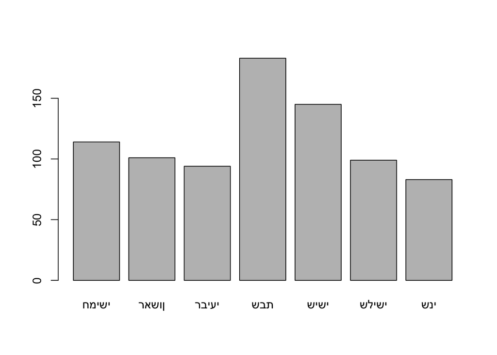

```r
#barplot(table(weekdays(as.Date(yem$Debut))),names.arg=c("Thu","Sun","Wed","Sat","Fri","Tue","Mon"))
barplot(table(weekdays(as.Date(yem$Debut))))
```

## Songs Left Behind

Some preparations

```r
cover <- format(yem$Original.Artist)
cover2 <- rep("Cover",length(cover))
cover2[cover == "Phish                                         "] <- "Original"
```

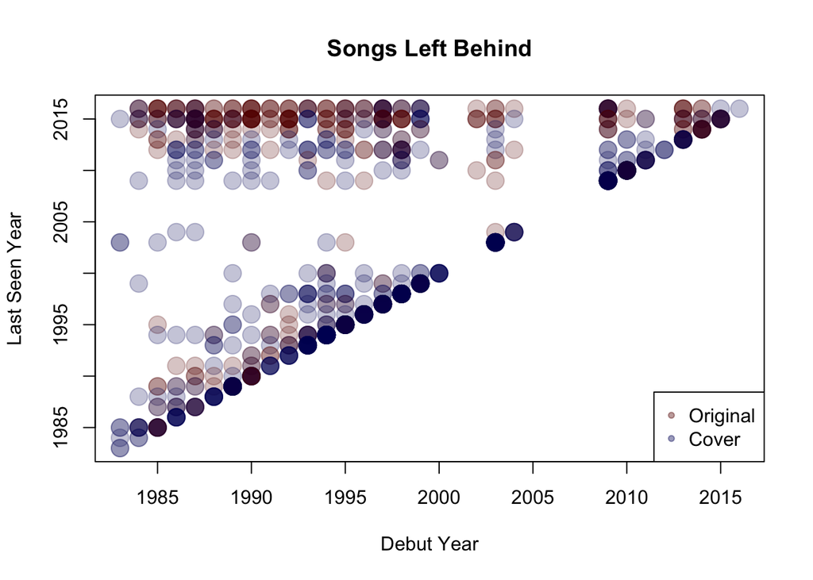

```r
plot(as.numeric(format(as.Date(yem$Debut), "%Y")),as.numeric(format(as.Date(yem$Last.Seen), "%Y")), xlab="Debut Year", ylab="Last Seen Year",main="Songs Left Behind",pch=20,xlim=c(1983,2016),ylim=c(1983,2016), col=ifelse(cover2=="Original", rgb(100,0,0,60,maxColorValue=255),rgb(0,0,100,60,maxColorValue=255)), cex=3)
legend("bottomright",legend =c("Original","Cover"),col=c(rgb(100,0,0,100,maxColorValue=255),rgb(0,0,100,100,maxColorValue=255)),pch=20)
```

## Bust out

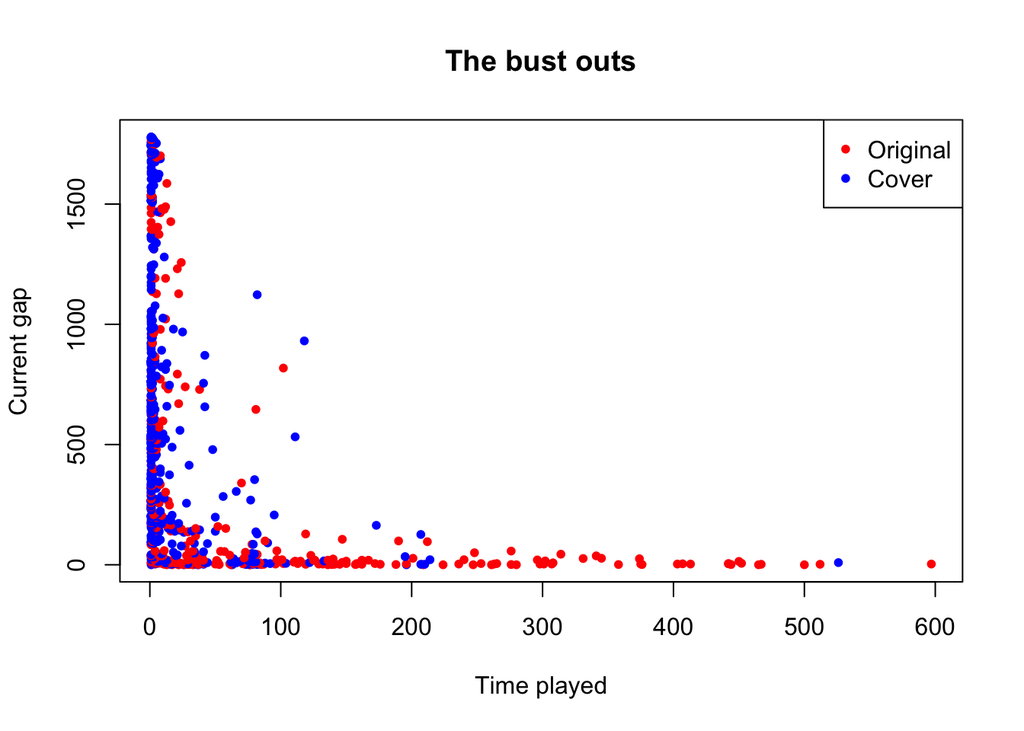

```r
plot(yem$Times.Played,yem$Current.Gap,col=ifelse(cover2=="Original","red","blue"),pch=20,cex=1,main="The bust outs",xlab="Time played",ylab="Current gap")
legend("topright",legend =c("Original","Cover"),col=c("red","blue"),pch=20)
```

Self-Note - Phish is the greatest band for me. A band that changed my entire life and made the person I am. Ido